# Aula 3: Continuação da análise do pêndulo

## Objetivos

Dar continuidade à análise dos dados de oscilação de pêndulos de diferentes comprimentos.

- Continuar a análise dos dados dos ensaios de iluminância.
- Novos ensaios, usando o sensor de proximidade.
- Ajustes lineares e quadráticos.

## Pêndulo esquematizado

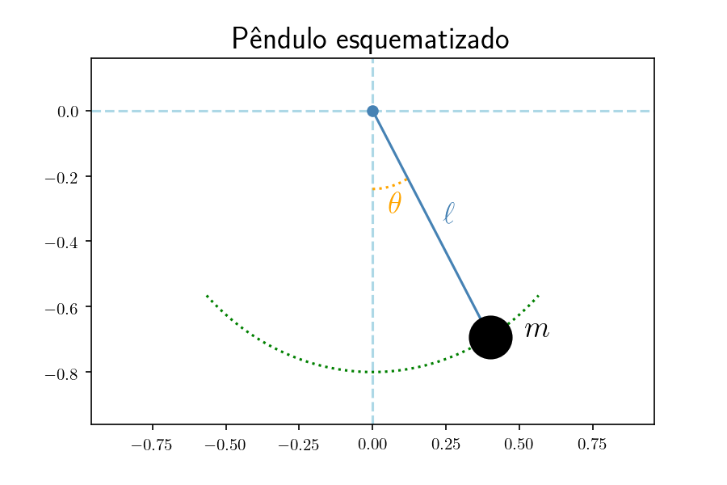

```python
from os import path
from IPython.display import Image
Image(filename=path.join('..', 'dados', 'pendulo', 'pendulo_esquematizado.png'), width=600)
```

## Hipóteses e modelo

- A força da gravidade exercida no pêndulo é decomposta em compontentes tangencial e normal ao movimento circular do mesmo.
- A tensão na haste exerce uma força no objeto em direção ao ponto fixo da haste.
- Despreza-se qualquer outra força.
- Despreza-se a elasticidade da haste.
- A diferença entre a tensão e componente normal da força gravitacional é a aceleração centrípeta, responsável por manter o objeto em movimento circular.
- A componente tangencial causa o movimento circular.

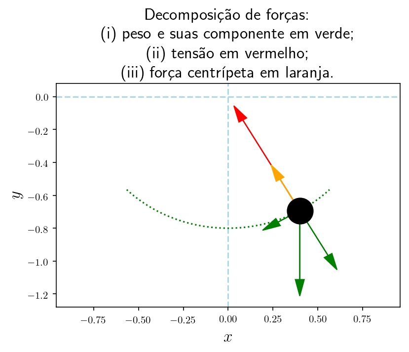

```python
Image(filename=path.join('..', 'dados', 'pendulo', 'pendulo_forcas.png'), width=340)
```

## Aproximação linear do modelo

- Assumindo uma oscilação pequena, usamos a aproximação

$$ \sin\theta \approx \theta, \qquad (\text{para } |\theta| \ll 1 ). $$

- Isso nos dá a equação linear de segunda ordem

$$ \ell\theta'' = - g \theta. $$

- Suas soluções:

$$ \theta(t) = C_1 \sin\left(\sqrt{\frac{g}{\ell}} t\right) + C_2 \cos\left(\sqrt{\frac{g}{\ell}} t\right) = A \cos\left(B + \sqrt{\frac{g}{\ell}} t\right), \qquad \forall t\in \mathbb{R}. $$

com $A$ pequeno. O ângulo inicial é $\theta_0 = A\cos(B)$ e a velocidade angular inicial é $\omega_0 = A\sqrt{g/\ell}\sin(B)$, onde $A$ é a amplitude e $B$ é a fase temporal.

- No caso de um pêndulo "largado" de um ângulo $\theta_0$, temos $\omega_0 = 0$, de onde tiramos $A=\theta_0$ e $B=0$, com solução

$$ \theta(t) = \theta_0 \cos\left(\sqrt{\frac{g}{\ell}} t\right), \qquad \forall t\in \mathbb{R}. $$

## Período de oscilação

- Da solução

$$ \theta(t) = A \cos\left(B + \sqrt{\frac{g}{\ell}} t\right), \qquad \forall t\in \mathbb{R}. $$

e da periodicidade do cosseno, extraímos o **período $T$ de oscilação**:

$$ \sqrt{\frac{g}{\ell}} T = 2\pi \quad \Longrightarrow T = 2\pi\sqrt{\frac{\ell}{g}}. $$

Escrevendo o comprimento em função do período:

$$ \ell = \frac{g}{4\pi^2} T^2. $$

## Gráfico da solução do problema linear

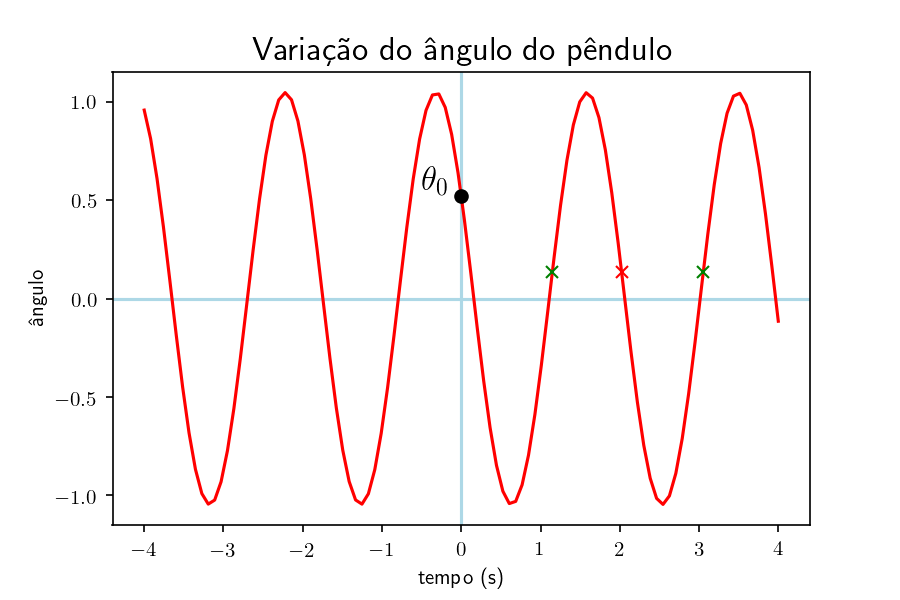

```python
Image(filename=path.join('..', 'dados', 'pendulo', 'solucao_aprox_linear.png'), width=600)
```

## Ensaios com o sensor de luminância

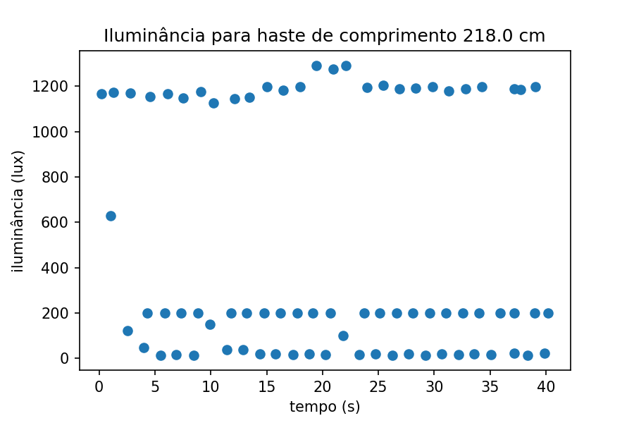

```python
Image(filename=path.join('..', 'dados', 'pendulo', 'ensaios_luminancia_218.0cm.png'), width=400)
```

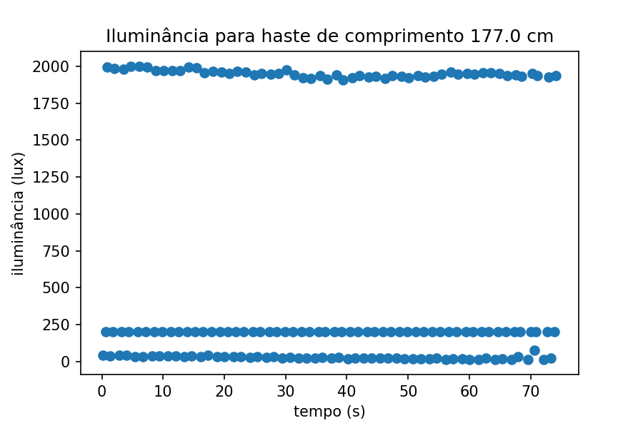

```python
Image(filename=path.join('..', 'dados', 'pendulo', 'ensaios_luminancia_177.0cm.png'), width=400)
```

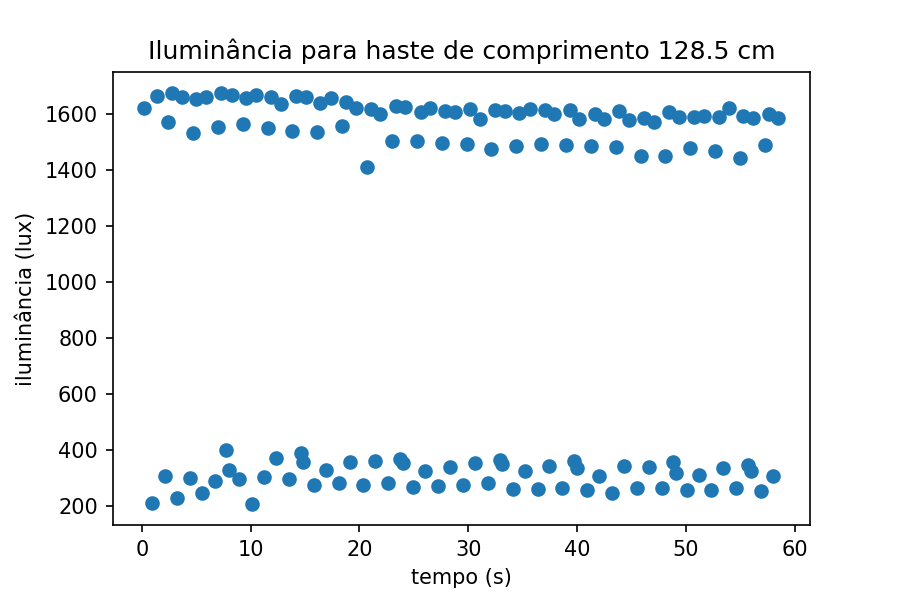

```python
Image(filename=path.join('..', 'dados', 'pendulo', 'ensaios_luminancia_128.5cm.png'), width=400)
```

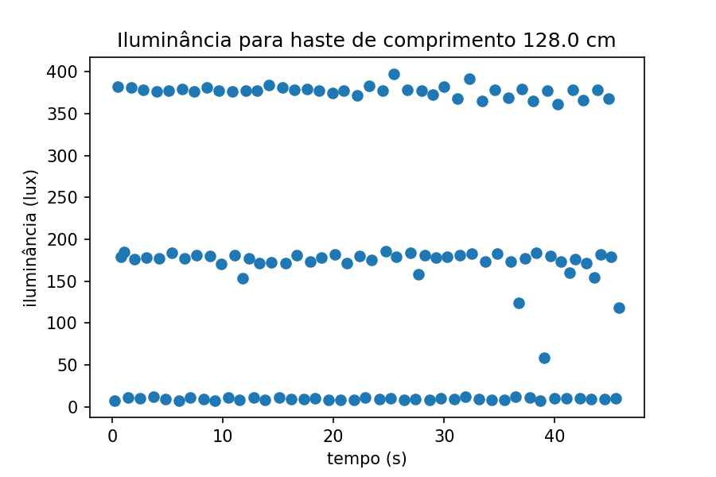

```python
Image(filename=path.join('..', 'dados', 'pendulo', 'ensaios_luminancia_128.0cm.png'), width=400)
```

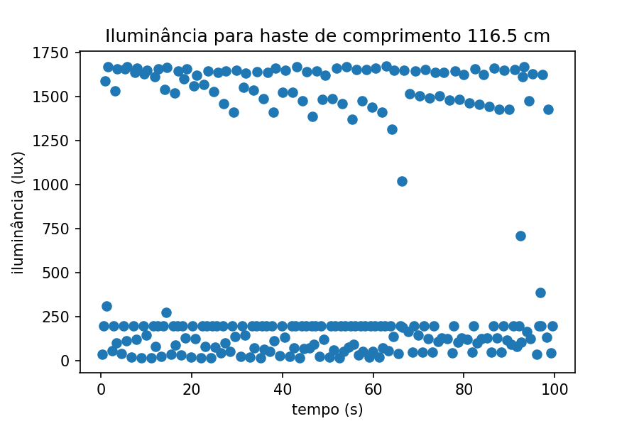

```python
Image(filename=path.join('..', 'dados', 'pendulo', 'ensaios_luminancia_116.5cm.png'), width=400)
```

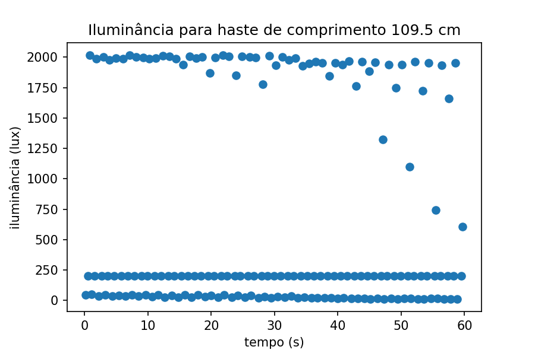

```python
Image(filename=path.join('..', 'dados', 'pendulo', 'ensaios_luminancia_109.5cm.png'), width=400)
```

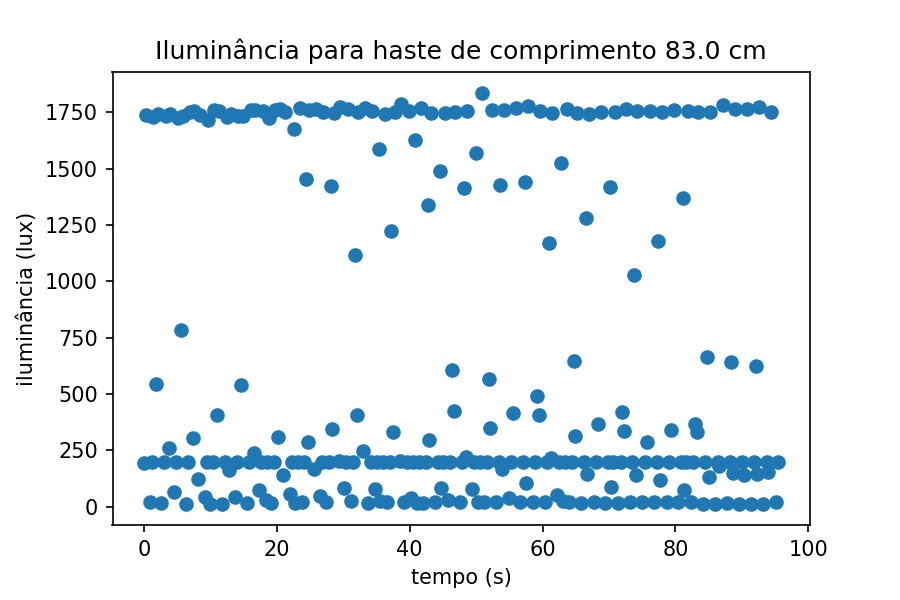

```python
Image(filename=path.join('..', 'dados', 'pendulo', 'ensaios_luminancia_83.0cm.png'), width=400)
```

## Experimento caseiro via sensor de proximidade

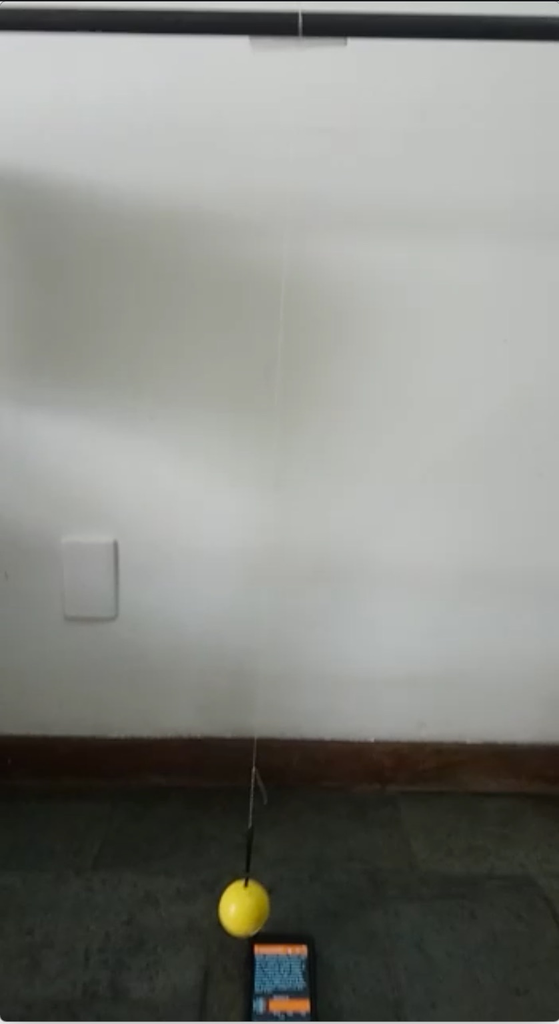

```python
Image(filename=path.join('..', 'dados', 'pendulo', 'experimento_pendulo_proximidade1.jpg'), width=200)
```

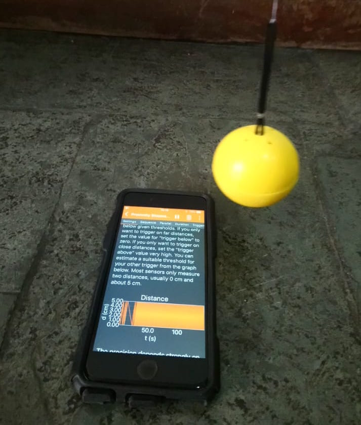

```python
Image(filename=path.join('..', 'dados', 'pendulo', 'experimento_pendulo_proximidade2.jpg'), width=400)
```

### Três ensaios

- Fio de $19\,\texttt{cm}$ e um ângulo inicial de aproximadamente $0.26$ radianos (ou $\arctan(5\,\texttt{cm}\,/\,19\,\texttt{cm})$, ou ainda $14,8$ graus).
- Fio de $36\,\texttt{cm}$ e um ângulo inicial de aproximadamente $0.27$ radianos (ou $\arctan(10\,\texttt{cm}\,/\,36\,\texttt{cm})$, ou ainda $15,5$ graus).
- Fio de $80\,\texttt{cm}$ e um ângulo inicial de aproximadamente $0.14$ radianos (ou $\arctan(11,2\,\texttt{cm}\,/\,80\,\texttt{cm})$, ou ainda $8$ graus).

Nos dois últimos ensaios, com fios mais longos, os ângulos iniciais foram medidos tanto pela distância entre o objeto inicial e o eixo vertical, como pelo inclinômetro do celular. No ensaio do fio mais curto, apenas a distância entre o objeto e o eixo vertical foi tomada.

No primeiro ensaio, o sensor não funcionou muito bem e, aparentemente, "pulava" uma das passagens.

## Os arquivos

- No diretório `/dados/pendulo/`, temos vários arquivos de dados, correspondendo a experimentos com pêndulos de diferentes comprimentos.
- Os arquivos com o sensor de iluminância são da forma `pend_l*.csv` e começaram a ser trabalhados na última aula.
- Os arquivos com o sensor de proximidade são da forma `pendulo_sensor_de_proximidade_l*_theta*.csv`, onde o primeiro grupo `*` indica o comprimento do fio, em centímetros, e o segundo grupo `*`, o ângulo inicial, em radianos, em que o objeto é largado.

### Nome de cada arquivo

```python
from os import path, listdir

nome_arquivos = [f for f in listdir(path.join('..', 'dados', 'pendulo')) if 'pendulo_sensor_de_proximidade' in f]
for nome in nome_arquivos:
    print(nome)
```

```
pendulo_sensor_de_proximidade.csv
pendulo_sensor_de_proximidade_l19cm_theta0.26.csv
pendulo_sensor_de_proximidade_l36cm_theta0.27.csv
pendulo_sensor_de_proximidade_l80cm_theta0.14.csv
```

- O primeiro arquivo, `pendulo_sensor_de_proximidade.csv`, não teve os sua informação de comprimento do fio registrado. Em um primeiro momento, este arquivo pode ser ignorado. De curiosidade, pode-se usar os seus dados para se estimar o comprimento do fio utilizado.

## Lendo os comprimentos e os ângulos

```python
import re
reg = re.compile(r'(\bpendulo_sensor_de_proximidade_l)([\d]*)(cm_theta0.)([\d]*).csv')
comprimentos_prox = [reg.match(f).group(2) for f in listdir(path.join('..', 'dados', 'pendulo')) if reg.match(f)]
theta0_prox = [reg.match(f).group(4) for f in listdir(path.join('..', 'dados', 'pendulo')) if reg.match(f)]

for j in range(len(comprimentos_prox)):
    comprimentos_prox[j] = float(comprimentos_prox[j])
    theta0_prox[j] = float(theta0_prox[j])/100

print(f'Comprimentos: {comprimentos_prox}, em centímetro')
print(f'Ângulos de oscilação: {theta0_prox}, em radianos')
```

```
Comprimentos: [19.0, 36.0, 80.0], em centímetro
Ângulos de oscilação: [0.26, 0.27, 0.14], em radianos
```

## Extraindo o período de oscilação do pêndulo

- Da informação de de proximidade, podemos extrair o **período** de oscilação do pêndulo.
- É preciso levar em conta que pode haver erros no processo de medição, tanto na montagem do aparato como no de obter os dados.
- Um devido tratamento dos dados é necessário.

## Exercícios:

1. Leia cada um dos arquivos;
2. Faça um gráfico dos dados em função do tempo (tanto pelo sensor de iluminância como pelo de proximidade);
3. Extraia, desses dados, o período de oscilação do pêndulo;
4. Faça um gráfico do período médio de cada ensaio em função do comprimento da haste;
5. Faça um gráfico do comprimento da haste em função do período médio de cada ensaio;
6. Faça um ajuste quadrático buscando a relação $\ell \propto T^2$ e extraia a constante de proporcionalidade;
7. Compare diferentes ajustes do tipo $p_1(T) = bT + c$, $p_2(T) = aT^2 + bT +c$, $p_3(T) = aT^2 + bT$, $p_4(T) = aT^2$.
8. Da constante de proporcionalidade em $\ell \propto T^2$ e usando a aproximação pelo modelo linar, extraia uma aproximação para a aceleração da gravidade e compare com o valor tabulado de $g = 9,8 \;\texttt{m}\,/\,\texttt{s}^2$.

## Relatório

Fazer um relatório sobre o que foi discutido e pedido nas aulas 2 e 3 e entregar **até quinta-feira (28/março)** para

- Alejandro Cabrera alejandro@matematica.ufrj.br
- Ricardo Rosa rmsrosa@gmail.com

```python
!jupyter nbconvert 03.00-Aula3.ipynb --to slides
```